# Quality Machine

This notebook is based on the results in [‘Quality Minus Junk’](http://www.econ.yale.edu/~shiller/behfin/2013_04-10/asness-frazzini-pedersen.pdf) by Asness, Frazzini and Pedersen. Their methodology includes long/short portfolios and in-sample estimated predictors of a company’s future default probability. Furthermore, ad hoc choices are made regarding weighting of quality measures and stocks in the actual portfolio. These choices make it virtually impossible to replicate the portfolio in reality. All these objections are handled by creating a factor that is a long-only portfolio assembled by a Random Forest. This machine learning mechanism is fed with balance sheet and stock return data of companies that existed in the last 5 years. In-sample estimated series are not included. The random forest learns from this data and applies the resulting decision rules to current book data. This approach gives similar results as the original paper, so it appears that the existence of the quality premium is robust to the author’s methodology.

```r
require(xts)
require(PerformanceAnalytics)
require(TTR)
require(randomForest)
require(plyr)
require(ggplot2)
require(scales)
require(reshape2)
require(gridExtra)
```

# Introduction

Based on empirical results [Asness et al. [2014]](http://www.econ.yale.edu/~shiller/behfin/2013_04-10/asness-frazzini-pedersen.pdf) suggest the existence of a quality premium. They argue that investors should be willing to pay more for stocks that are:

- safe,
- profitable,
- growing,
- and well managed.

These four properties of a company can be translated to more or less quantifiable characteristics. While diverse profitability measures exist in the accounting literature, measuring how well a company is managed is hardly possible. However, five characteristics that relate the basic principles above to balance sheet data emerge:

- Profitability
- Growth
- Safety
- Payout
- Book-to-Market

# Methodology

## Random Forest

A Random Forest consists of many decision trees. Each tree is grown to explain return as a function of measures of these 5 characteristics above. In doing so following steps are carried out:

- bootstrap training data from original data,
- create decision trees on each bootstrap sample,
- randomly select only a subset of predictors,
- use non-selected observations as test data within each tree
- average over predictions - which is called bagging.

## Data

All measures for the characteristics are taken from Asness et al. [2014].

### Profitability

Profitability is measured by:

- Revenue minus costs of goods sold divided by total assets (GPOA)
- Net income divided by book equity (ROE)
- Net income plus depreciation minus changes in working capital and capital expenditures divided by total assets (CFOA)
- Revenue minus costs of goods sold divided by total sales (GMAR)
- Depreciation minus changes in working capital, where working capital is current assets minus current liabilities minus cash and short term instruments plus short term debt and income taxes payable (ACC)
- Shareholders’ equity minus preferred stock (BE)

### Growth

Growth is measured by 5-year growth in the six profitability values above.

### Safety

Safety is measured by:

- Negative market beta (BAB)
- Negative idiosyncratic volatility (IVOL)
- Negative total debt divided by total assets (LEV)
- Ohlson’s O-Score, in Ohlson [1980]
- Altmann’s Z-Score, in Altman [1968]
- Negative standard deviation of quarterly return on equity over the past 60 quarters (EVOL)

### Payout

Payout is measured by:

- Minus one-year percent change in split-adjusted number of shares (EISS)
- Minus one-year percent change in total debt (DISS)
- Sum of total net payout (NPOP)

### Book to Market

Book-to-Market is measured by dividing book equity by market equity.

The following graph shows *GPOA*, *Book-to-Market*, *BAB*, and *NPOP* data for some companies:

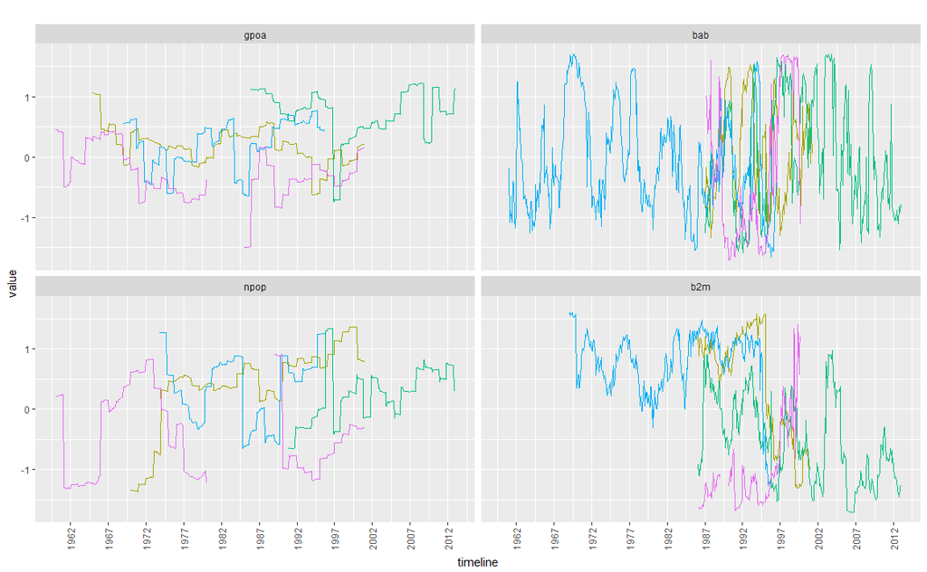

## Benchmark - Long Only

The benchmark portfolio mimics the portfolio constructed in Asness et al. [2014] in almost all characteristics. The only differences are that it is long only as opposed to long/short, and it weights stocks equally as opposed to linearly. In Asness et al. [2014] the top 30 percent quality stocks are bought and the worst 30 percent quality stocks are shorted. Their portfolio weights are linear in quality. E.g. the top-quality stock has large share in the portfolio, the lowest quality stock that is still bought has a tiny fraction. Since very small and very large positions are infeasible for a real portfolio manager, the benchmark portfolio weights bought stocks equally. Shorting stocks is also too often infeasible in reality, therefore the benchmark portfolio is long-only. The quality measure methodology from Asness et al. [2014] is replicated well as possible. Therefore, measures for each of the five characteristics are aggregated by first standardizing them, summing them up and again standardizing the result. This yields values for each of the characteristics. The higher these values, the better the quality. In the final aggregation step, the mean of these five characteristics is calculated.

## Random Forest

The random forest portfolio is created on the basis of predicted return. The companies with the top 10 percent predicted return are bought into the portfolio with equal weights. The return prediction is done using the same balance sheet data in two set ups. At first Altmann’s Z and Ohlson’s O score are still included, then they are not used as predictors. At each portfolio decision point a forest with 1000 decision trees is grown. Each tree tries to explain annualized returns in the past 5 years as a function of balance sheet data from 5 years ago:

$r_{t,t-59} = tree(x_{t-59}) + \epsilon_t$

For prediction purposes each tree generates a forecast, the final prediction is the mean over the individual ones:

$\hat{r}_{t+12,t} = \text{mean} {(\{t(x_t): t \in forest\})}$

The following code snipplets show how the random forest is grown and evaluated for one time period.

```r
set.seed(415) #for reproduceability
stocks_max_abs <- 100
perc_chosen <- 10
#build forest each monthly t with companies that have data today and utilizing up to past 5 years.
t <- 205 #chosen time period
pool <- !is.na(CRSPreturn[t,]) #number of buyable stocks

# which stocks have a return variable AND nonempty variables
objects <- ls(pattern="^m")
for (i in 1:length(objects)) {
    pool <- pool * !is.na(get(objects[i])[t-1,])
  }
(sum(pool)>=50)
```

```
[1] TRUE
```

```r
# at least 50 buyable stocks are available
```

```r
# rows with an NA represent stocks which are not available today
  # hence drop rows with NAs
  availabledata <- as.data.frame(data[apply(data,1,function(x) sum(!is.na(x))==length(x)),])
# RANDOM FOREST
  # train random forest with 1000 trees
  fit <- randomForest(ret ~ ., data=availabledata, importance=TRUE, ntree=1000)

# predict returns based on variables available today
  pred <- predict(fit,newdata, predict.all=TRUE)
```

```r
pred <- pred$aggregate
  # predict the returns of next period (t+1)
  # but if today not available it cannot be bought, therefore it has to be removed
  pred[is.na(CRSPreturn[t,])] <- NA

# now get the returns of the top 10% stocks
  stocks_in_universe <- sum(!is.na(pred))
  returns <- CRSPreturn[t+1,rank(-pred)<=ceiling(max(min(stocks_max_abs,stocks_in_universe*perc_chosen/100),20))]
  # top 10% minium 20 maximum 100 socks
  returns[is.na(returns)] <- -1 #fill conservativly!
  # invest equally in each stock
  performance[t+1,1] <- mean(returns)
```

# Results

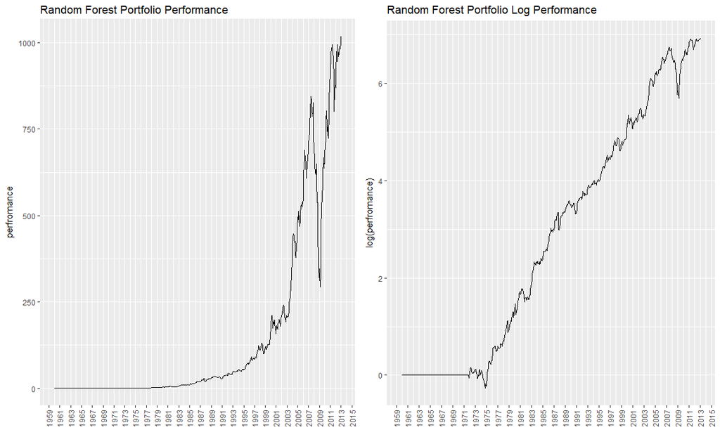

One can see the good development of the random forest portfolio with some kind of break after 2008, the financial crisis.

## With/Without Z and O

The random forest portfolio without Z and O score (dark red) performs as well, even a bit better, than the random forest portfolio utilizing the two predictors (red). The results show that the benchmark portfolio (black) has similar results as the factor in Asness et al. [2014]. The random forest portfolio in this set up does so even more, indicating that the existence of the quality premium is not dependent on the standardization of measures of characteristics or linear weighting of portfolio positions.

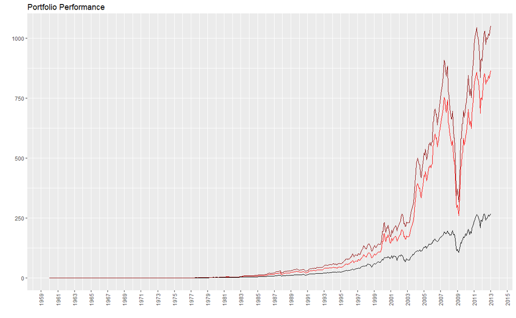

Annualized results are:

| Results | Benchmark | RF | RF w/o Z and O |
| --- | --- | --- | --- |
| Annualized Return | 0.1493 | 0.1808 | 0.1875 |
| Annualized Std Dev | 0.1755 | 0.2140 | 0.2107 |
| Annualized Sharpe | 0.5408 | 0.5840 | 0.6237 |

# Robustness

Let’s take a look at the uncertainty of the forest. The variance within the trees for every single stock was calculated and the difference between the maximum and the minimum variance was chosen as the measure of uncertainty. It would be interesting to know, whether or not the performance of the random forest portfolio is sensitive to the forest’s uncertainty.

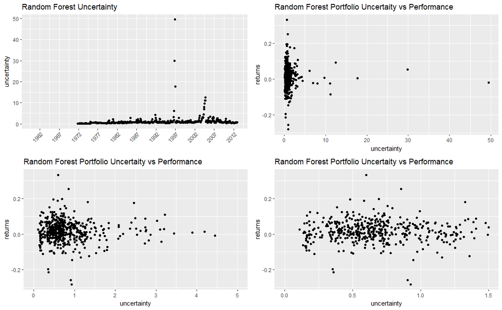

There seems to be no relationship between performance and uncertainty.

# Conclusion

In conclusion, the results in Asness et al. [2014] seem to be robust to the objections raised. Abandoning the ad hoc choices of long/short portfolios, linearly weighted portfolio positions, and standardization and equal weighting of measures and characteristics does not change the results to the worse. Both Altmann’s Z score and Ohlson’s O score, which are estimated in-sample, can be left out without weakening the claim of the existence of the quality premium.